# Part iA: Predictors (Lexicon: NRC)

INFSCI 2595 Final

Ben Stein

4/27/2022

# About this document

In this document, I perform exploratory data analysis on the variables from the NRC lexicon data.

# Setup

## Libraries and tools

```r
library(tidyverse)
source("./tools.R")
```

## Data

```r
df <- load_project_data() %>%
  select(response_log, outcome_numeric, starts_with("xn"))

df %>% glimpse
```

```
## Rows: 677
## Columns: 10
## $ response_log    <dbl> 0.9624073, 0.1694321, 0.7959862, 1.0030975, 0.3942847,~
## $ outcome_numeric <dbl> 0, 0, 1, 0, 0, 0, 0, 0, 0, 0, 0, 0, 0, 0, 0, 0, 0, 1, ~
## $ xn_01           <dbl> 3.0000000, 2.0000000, 2.0000000, 1.5333333, 0.8387097,~
## $ xn_02           <dbl> 3, 2, 4, 9, 3, 8, 6, 10, 10, 4, 6, 8, 9, 5, 7, 12, 12,~
## $ xn_03           <dbl> 3, 2, 0, -3, -4, -2, -5, -6, -3, -5, -3, -6, -4, -3, 0~
## $ xn_04           <dbl> 1.0000000, 2.0000000, 1.0000000, 0.5268889, 0.4688172,~
## $ xn_05           <dbl> 1.0000000, 2.0000000, 0.0000000, -1.0000000, -1.333333~
## $ xn_06           <dbl> 1.0, 2.0, 2.0, 2.5, 3.0, 2.0, 4.0, 4.0, 3.0, 2.0, 2.0,~
## $ xn_07           <dbl> 3.000000, 2.000000, 2.500000, 1.493333, 1.225806, 1.64~
## $ xn_08           <dbl> -1.0000000, 2.0000000, -1.0000000, -0.4400000, -0.4516~
```

# Distributions

Let’s look at the distributions of the variables first.

```r
df %>%
  select(starts_with("xn")) %>%
  summary
```

```
##      xn_01             xn_02            xn_03             xn_04
##  Min.   :-4.0000   Min.   :-4.000   Min.   :-7.0000   Min.   :-4.0000
##  1st Qu.: 0.7917   1st Qu.: 2.000   1st Qu.:-2.0000   1st Qu.: 0.2678
##  Median : 1.6000   Median : 4.000   Median :-1.0000   Median : 0.6000
##  Mean   : 1.5581   Mean   : 3.665   Mean   :-0.4018   Mean   : 0.6038
##  3rd Qu.: 2.4000   3rd Qu.: 6.000   3rd Qu.: 1.0000   3rd Qu.: 1.0000
##  Max.   :10.0000   Max.   :13.000   Max.   :10.0000   Max.   : 5.0000
##      xn_05             xn_06            xn_07            xn_08
##  Min.   :-4.0000   Min.   :-4.000   Min.   :-4.000   Min.   :-4.00000
##  1st Qu.:-1.0000   1st Qu.: 0.800   1st Qu.: 1.000   1st Qu.:-1.00000
##  Median :-0.2500   Median : 1.250   Median : 1.400   Median :-0.30769
##  Mean   :-0.1584   Mean   : 1.479   Mean   : 1.406   Mean   :-0.26713
##  3rd Qu.: 0.5000   3rd Qu.: 2.000   3rd Qu.: 1.833   3rd Qu.: 0.03704
##  Max.   : 5.0000   Max.   : 7.000   Max.   : 5.000   Max.   : 5.00000
```

Like other groups of sentiment variables, these inputs have differing scales and will thus need preprocessing.

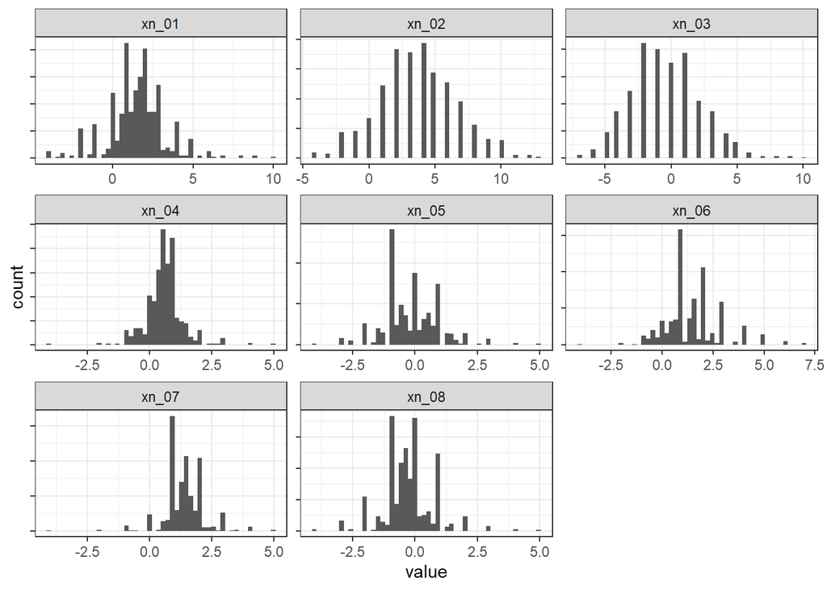

```r
visualize_distributions(df, "xn")
```

As we’ve probably come to expect, these variables have approximately normal distribution, especially the lower-numbered ones.

## Distinct values

As I worked with each group of continuous predictors, I noticed that some seem to have more unique values than others. Let’s quantify that:

```r
df %>%
  select(starts_with("xn")) %>%
  pivot_longer(cols = everything()) %>%
  group_by(name) %>%
  unique %>%
  count
```

```
## # A tibble: 8 x 2
## # Groups:   name [8]
##   name      n
##   <chr> <int>
## 1 xn_01   225
## 2 xn_02    18
## 3 xn_03    18
## 4 xn_04   360
## 5 xn_05    51
## 6 xn_06    47
## 7 xn_07   174
## 8 xn_08   174
```

As we can see, some inputs have high ranges of values, while others do not. This may affect our choices for modeling later.

# Correlation within the group

Let’s see if any of these inputs are correlated with one another.

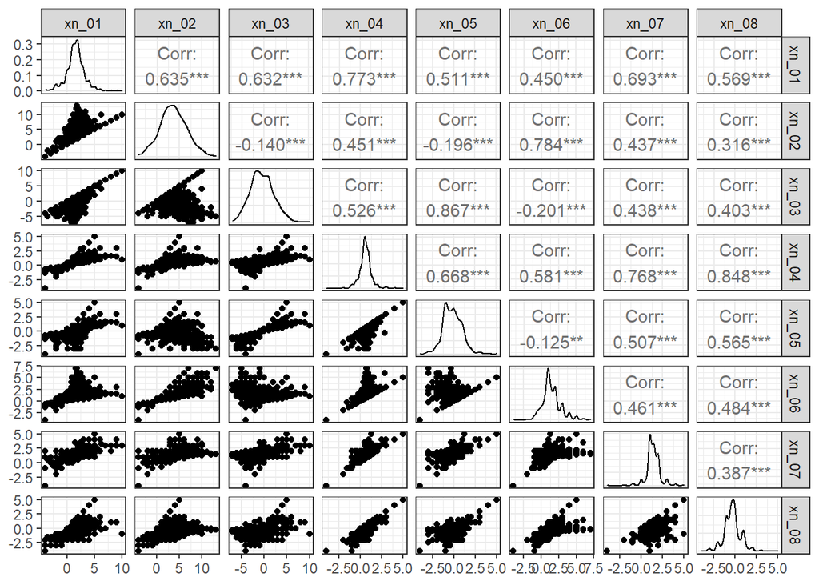

```r
visualize_correlations(df, "xn")
```

Like prior lexicons, input 1 is correlated highly with other inputs. 4 and 7 seem to be also.

# Relationship to target variables

## The continuous `response` variable

Note that I log-transformed response since that’s what I’ll be predicting anyway.

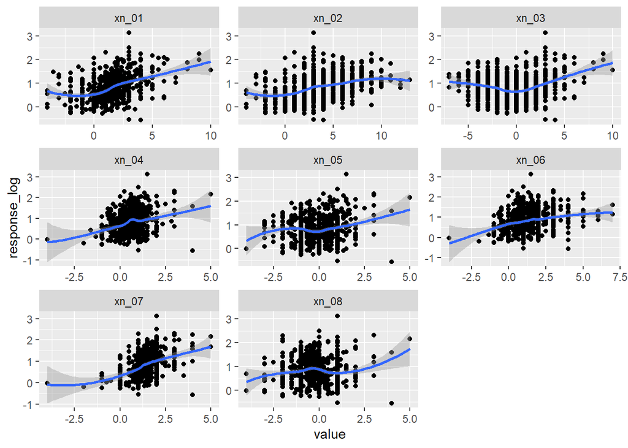

```r
df %>%
  pivot_longer(cols = starts_with("xn")) %>%
  ggplot(mapping = aes(x = value, y = response_log)) +
  geom_point() +
  geom_smooth(formula = y ~ x, method = "loess") +
  facet_wrap(~ name, scales = "free")
```

Like the other lexicons, the loess lines are nearly (but not exactly) linear. Based on this figure and the corresponding ones for other groups, I’m interested in using splines to model them.

## The `outcome` classification target

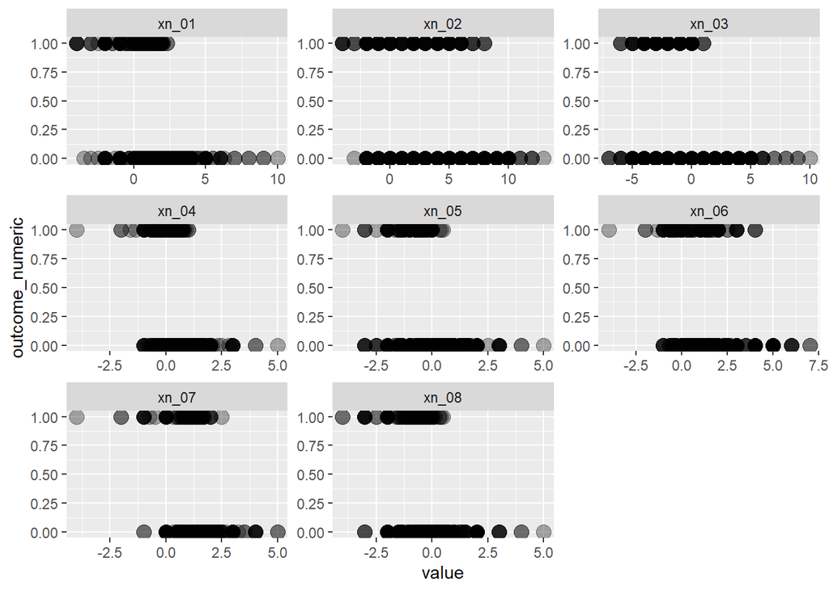

```r
df %>%
  select(-response_log) %>%
  pivot_longer(cols = starts_with("xn")) %>%
  ggplot(mapping = aes(x = value, y = outcome_numeric)) +
  geom_point(size = 4, alpha = .33) +
  facet_wrap(~ name, scales = "free")
```

Of all of the predictor groups evaluated so far, this one has the strongest separation between events and non-events, with lower values of each predictor seeming to correlate with the event occurring. This may suggest that we want to lean on the NRC lexicon during classification modeling.